# DSCI 100 - Introduction to Data Science

## Lecture 2 - Getting data into Python

[figure not shown]

## Housekeeping

- If you registered late to the class:
  - any assignment from a class that happened before you registered is due **1 week after you registered**
  - any assignment from a class that happened after you registered is due **at the regular time**
- Office hours (see syllabus):
  - Please feel free to drop by ANY office hours regardless of the section that you are in
- Remember: when in doubt,
  - **Kernel -> Restart Kernel and Run All** (or the ▶▶ button)
- When you are working on assignments there is a cell that says

```
DOUBLE CLICK TO EDIT THIS CELL AND REPLACE THIS TEXT WITH YOUR ANSWER
```

**make sure you double click and edit that cell directly.** Your question won't be graded otherwise.

- Shut down server when you are done working

## So far...

- Introduction to
  - Python programming and Jupyter notebooks
  - a sprinkle of data analysis

## Now...

Taking our first step in data analysis: loading data into Python!

## Why are we using programming languages to do data analysis?

### And why can't I just use Excel???

vs.

[figure not shown]

- There are many advantages to using Python (or another language, like R or Julia):
  - statistical analysis functions that go beyond Excel
  - free and open-source
  - transparent & reproducible code
  - can handle large amounts of data and complex analyses
- Using a programming language is like baking with a recipe:
  - Ingredients = data

[figure not shown]

  - Recipe = code

[figure not shown]

- Someone else can use your recipe (code) to bake the same cake (produce the same data analyses)
- Spreadsheets in Excel make it *very* difficult to understand where results came from

**In the data science workflow** (source: Grolemund & Wickham, [R for Data Science](https://r4ds.had.co.nz/))

[figure not shown]

## Loading/importing data

- 4 most common ways to do this in Data Science
  1. **read in a text file with data in a spreadsheet format**
  2. **read from a database (e.g., SQLite, PostgreSQL)**
  3. scrape data from the web (optional bonus material)
  4. use a web API (Application Programming Interface) to read data from a website (not covered in DSCI100)

## Different ways to locate a file / dataset

**Local (on your computer)**

- An *absolute* path locates a file with respect to the "root" folder on a computer
  - starts with `/`

    e.g. `/home/instructor/documents/timesheet.xlsx`
- A *relative* path locates a file relative to your *working directory*
  - doesn't start with `/`

    e.g. `documents/timesheet.xlsx`  
    (where working directory is `/home/instructor/`)

**Remote (on the web)**

via "URL" that starts with `http://` or `https://`  
`http://traffic.libsyn.com/mbmbam/MyBrotherMyBrotherandMe367.mp3`

**Absolute vs relative paths: Which should you use?**

- Generally to ensure your code can be run on a different computer, you should use relative paths
- e.g. Alice is working inside the folder `/home/alice/project/`. To specify where to load data from in her Jupyter notebook, she uses the absolute path `/home/alice/project/data/happiness_report.csv`. What issue will arise when she shares the notebook with her collaborator Keeran who tries to read in the data on their computer?

`/home/keeran/project/data/happiness_report.csv`

- What relative data path could they use to collaborate more effectively?

`data/happiness_report.csv`

## Demo: Loading data from your computer

**Workflow:**.

1. Navigate to the file to see what it looks like
2. Prepare to load the data into Python
   - Might need to import a package, download a file, or connect to a database
3. Load the data into Python
   - Using `read_csv`
4. Inspect the result to make sure it worked

Let's load the Old Faithful geyser dataset from [Larry Wasserman's book All of Statistcs](https://www.stat.cmu.edu/~larry/all-of-statistics/)

https://www.youtube.com/watch?v=_gyhvqbIaOE

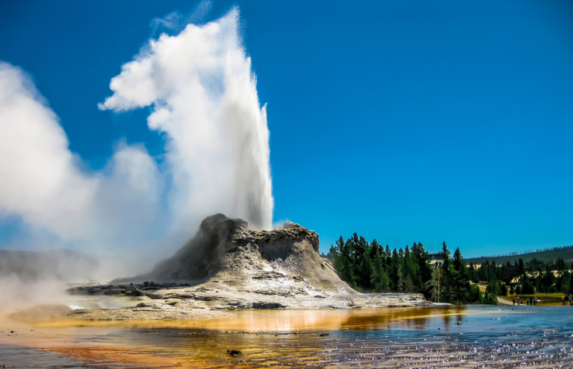

## What is a Geyser?

## What is the data?

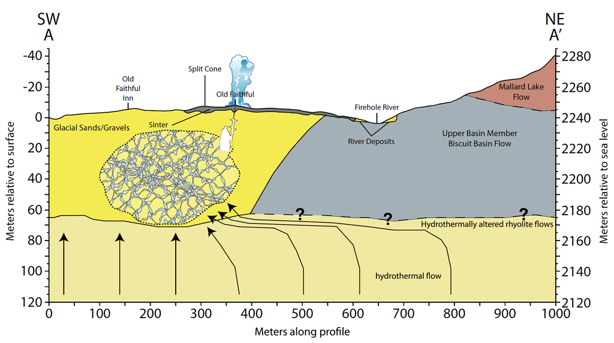

```python
# Step 1: Navigate to the data file to see what it looks like

my_url = 'https://www.stat.cmu.edu/~larry/all-of-statistics/=data/faithful.dat'
```

```python
# Step 2: Prepare to load the data into Python

# Import the Pandas library which contains all the `read_*` functions
import pandas as pd
```

```python
# Step 3: Load the data into Python
df = pd.read_csv(my_url, skiprows=24, sep='\s+')
df
```

|  | eruptions | waiting |
| --- | --- | --- |
| 1 | 3.600 | 79 |
| 2 | 1.800 | 54 |
| 3 | 3.333 | 74 |
| 4 | 2.283 | 62 |
| 5 | 4.533 | 85 |
| ... | ... | ... |
| 268 | 4.117 | 81 |
| 269 | 2.150 | 46 |
| 270 | 4.417 | 90 |
| 271 | 1.817 | 46 |
| 272 | 4.467 | 74 |

272 rows × 2 columns

```python
# Step 4: Inspect the result to make sure it worked (often done together with step 3)
df
```

|  | eruptions | waiting |
| --- | --- | --- |
| 1 | 3.600 | 79 |
| 2 | 1.800 | 54 |
| 3 | 3.333 | 74 |
| 4 | 2.283 | 62 |
| 5 | 4.533 | 85 |
| ... | ... | ... |
| 268 | 4.117 | 81 |
| 269 | 2.150 | 46 |
| 270 | 4.417 | 90 |
| 271 | 1.817 | 46 |
| 272 | 4.467 | 74 |

272 rows × 2 columns

## Notes about loading data

1. Its important to do it carefully + check results after! will help reduce bugs and speed up your analyses down the road Think of it as tying your shoes before you run; not exciting, but if done wrong it will trip you up later!
2. After you load the data you need to **look at the ... data** Does it make any sense?

## Questions?

## Go for it!

Work together on your worksheets and tutorials. **Collaborate, but do not copy! Learn from each other!**

## What did we learn?

## Note on web scraping

- More and more websites don't want you scraping
- They instead are providing "easier" ways for you to access the data as opposed to scraping it (which they can regulate and know who you are)
- So, TL;DR read the Terms of Service for ANY webpage you are planning on scraping
  - they're long to read, so search for "scraping", "auto", "bot", etc to find the relevant section